# Motor Trend Cars

Katie, Sarah, Meerim

March 4, 2016

## Data

This data is from Motor Trend magazine in 1974. It presents data for 32 automobiles regarding performance and design.

Variables:

```
##  [1] "mpg"  "cyl"  "disp" "hp"   "drat" "wt"   "qsec" "vs"   "am"   "gear"
## [11] "carb"
```

Explanation of variable names: mpg is miles per gallon; cyl is number of cylinders; disp is displacement (in cubic inches); hp is horsepower; drat is rear axle ratio; wt is weight (in 1000 pounds); qsec is 1/4 mile time; vs is engine type (0 = vertical/1 = straight); am is transmission type (0 = automatic, 1 = manual); gear is number of forward gears; and carb is number of carburetors

Basic statistics

```
##          mpg cyl disp   hp  drat    wt  qsec vs am gear carb
## nbr.val   32  32   32   32  32.0  32.0  32.0 32 32   32   32
## nbr.null   0   0    0    0   0.0   0.0   0.0 18 19    0    0
## nbr.na     0   0    0    0   0.0   0.0   0.0  0  0    0    0
## min       10   4   71   52   2.8   1.5  14.5  0  0    3    1
## max       34   8  472  335   4.9   5.4  22.9  1  1    5    8
## range     24   4  401  283   2.2   3.9   8.4  1  1    2    7
## sum      643 198 7383 4694 115.1 103.0 571.2 14 13  118   90
```

Means

```
## mpg 20.09
## cyl 6.19
## disp 230.72
## hp 146.69
## drat 3.6
## wt 3.22
## qsec 17.85
## vs 0.44
## am 0.41
## gear 3.69
## carb 2.81
```

# Plots

### Boxplot distributions: MPG

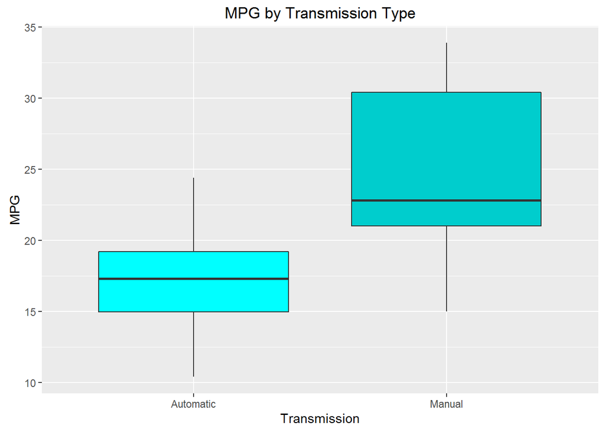

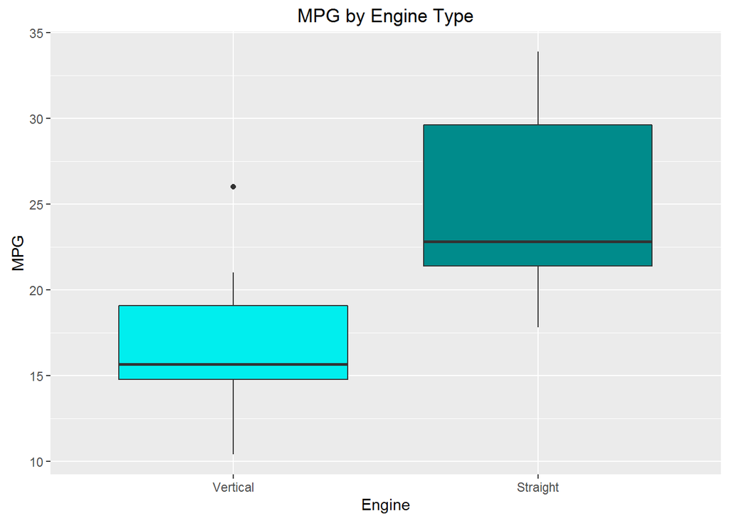

Manual transmissions and straight engines in this data set generally have better gas mileage.

### Boxplot distributions: Horsepower, Weight and Displacement

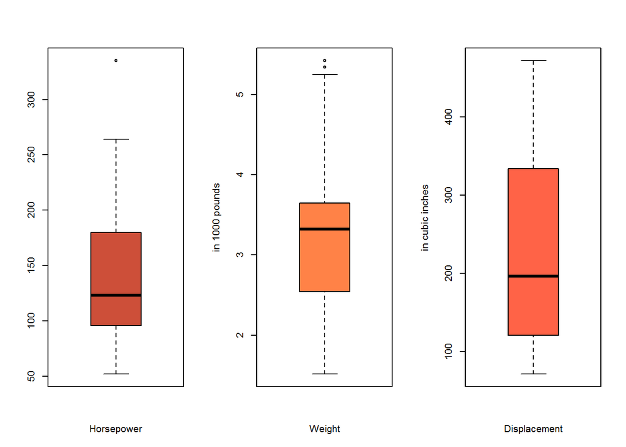

All three variables vary widely, but displacement has an especially wide distribution.

### Histograms of gear, carburetor and cylinder Variables

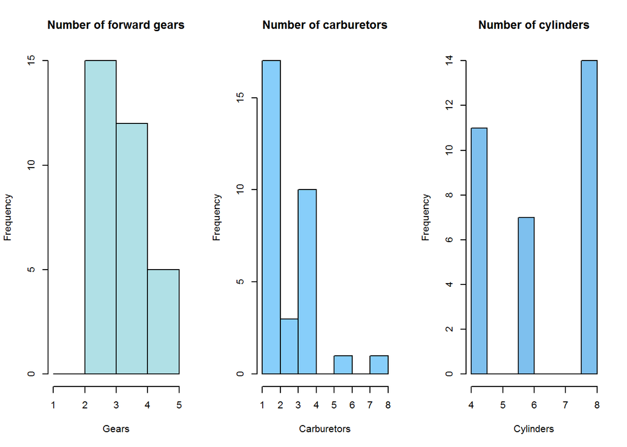

### Scatterplots showing correlation of variables with MPG, with lines of best fit and Lowess lines

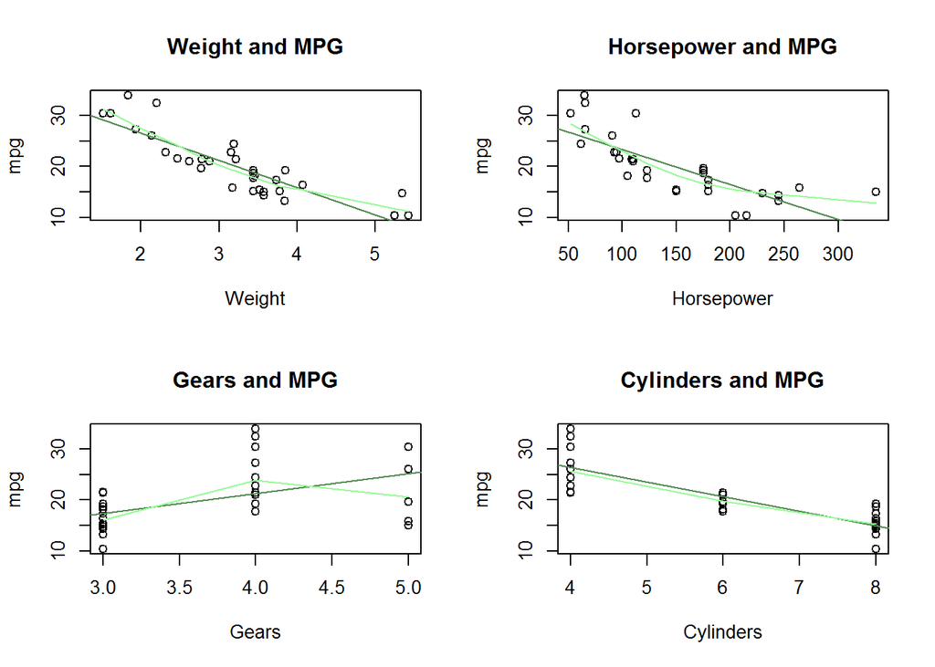

Weight, horsepower and cylinders are all negatively correlated with gas mileage. The number of gears does not appear to have a strong effect, though the best-fit line shows a slightly positve correlation.

### Scatterplots showing correlation of variables with quarter-mile time, with lines of best fit and Lowess lines

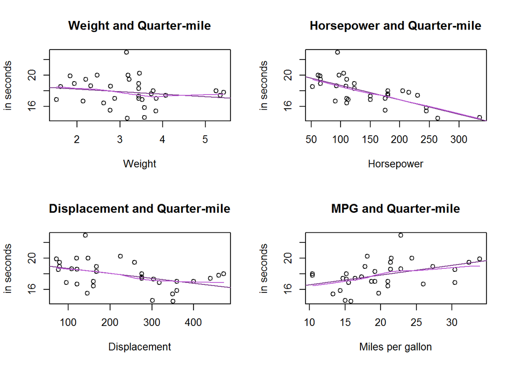

Horsepower and displacement are negatively correlated with the quarter-mile time, that is, cars with more horsepower or a larger engine have faster times. Weight shows a very slight negative correlation, too. Gas mileage and quarter-mile time are positively correlated: the better the gas mileage, the slower the time.